# Homework 2

## Problem 1 (2pts each, 8pts total)

Here are a few probability exercises to get you warmed up.

1. Consider $X\sim \text{Normal}(5, 2^2)$. Find $P(4 < X < 7)$

```r
p_4_7 <- pnorm(7, mean = 5, sd = 2) - pnorm(4, mean = 5, sd = 2)
p_4_7
```

```
## [1] 0.5328072
```

2. Suppose you have an uneven 6-sided die where the even numbers are equally likely to occur and the odd numbers are also equally likely. The expected value of the die is $3.3333$ (i.e. $\frac{10}{3})$. What is the probability of getting a 6? (Hint: Let $p$ represent the probability of getting an even number, and represent the probability of the other numbers algebraically. Then derive an expression for the expected value, let it equal $\frac{10}{3}$, and solve. You can go back and check your work by plugging the result back into your original expressions and verify it works with R.)

Let p be the probability of getting an even number. Since the die is uneven, even and odd numbers have different probabilities. The expected value equation is derived from the given die probabilities, and solving it will yield the probability of getting a 6.

```r
solve_for_p <- function() {
  eq <- function(p) {
    expected_value <- 3 * (1 - p) + 4 * p
    return(expected_value - 10/3)
  }
  uniroot(eq, c(0, 1))$root
}
p <- solve_for_p()
prob_6 <- p / 3
prob_6
```

```
## [1] 0.1111111
```

3. Give **two examples** of pairs of events that are mutually exclusive and explain why for each.

> Flipping a coin and getting heads or tails: These events cannot occur simultaneously, so they are mutually exclusive.

> Rolling a die and getting a 1 or a 2: On a single roll, you can only get one outcome, not both.
4. Give **two examples** of pairs of events that are independent and explain why for each.

> Flipping two different coins: The outcome of one coin flip does not affect the other.

> Rolling a die and drawing a card from a deck: The result of rolling the die does not influence which card is drawn.

## Problem 2 (2pts each, 14pts total)

For each of the following scenarios, decide what random variable may be appropriate to use as a model, and explain your reasoning as well as any assumptions you make.

1. The number of patients in an experimental drug trial that respond to treatment.

> Random Variable: Binomial

> Reasoning: Each patient either responds to treatment or not (binary outcome), and there is a fixed number of trials.
2. The number of red cars you observe driving through an intersection between 10am and 11am.

> Random Variable: Poisson

> Reasoning: The event occurs over a fixed time interval (10am-11am), and the number of cars is countable and unpredictable.
3. What the second hand reads on the clock when you wake up from a long nap (approximately).

> Random Variable: Discrete Uniform

> Reasoning: The second hand can land anywhere between 0 and 59 seconds with equal probability.
4. How many people you need to swipe right on Tinder before you get a match.

> Random Variable: Geometric

> Reasoning: You’re waiting for the first “success” (a match) after a sequence of swipes (failures).
5. The length of time between mosquito bites a camper experiences while on a hike.

> Random Variable: Exponential

> Reasoning: The event happens at a random time and follows a memoryless property typical of exponential distributions.
6. Whether the Eagles win the Superbowl this year.

> Random Variable: Bernoulli

> Reasoning: There are two possible outcomes: win or lose.
7. The GPA of a randomly selected UW-Madison graduate.

> Random Variable: Normal

> Reasoning: GPAs are likely normally distributed around a mean with some variance.

## Problem 3 (2pts each, 4pts total)

1. Consider the CDF given below for random variable $Y$

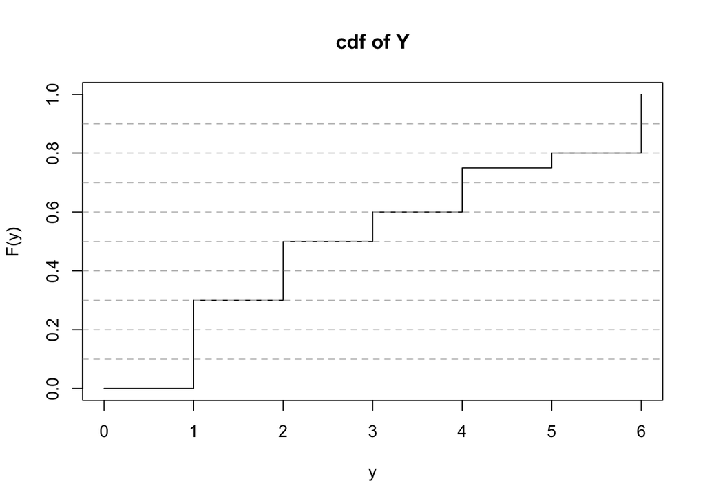

```r
plot(x=0:6, y=c(0,.3,.5, .6, .75,.8,1), type="s", ylab="F(y)", xlab="y", main="cdf of Y")
abline(h=seq(.1,.9,.1), lty=2, col="gray")
```

Express the pmf of $Y$ in the following R code (in other words, fill in the missing probabilities)

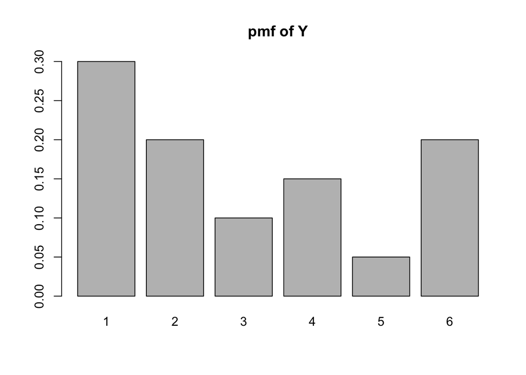

```r
y <- 1:6
py <- c(0.3, 0.2, 0.1, 0.15, 0.05, 0.2)
barplot(height=py, names=y, main="pmf of Y")
```

2. Calculate $E[Y]$ for the variable $Y$ in part a.

```r
E_Y <- sum(y * py)
E_Y
```

```
## [1] 3.05
```

## Problem 4 (2pts each, 4pts total)

Below you will find the plot of a probability density function for a random variable $X$.

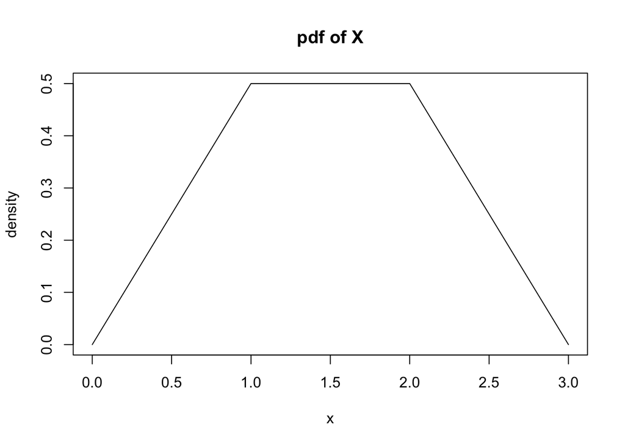

Using just geometry answer a and b:

1. What is $Pr[X < 1]$?

> 0.25 = 0.5 x 1 x 0.5
2. What is $Pr[1.5 < X < 2.5]$

> (0.5 x 0.5) + (0.5 x 0.25) + (0.5 x 0.25 x 0.5) = 0.4375